# Introduction to R

Laboratory of Statistics and Mathematics 2026/2027

Giuseppe Alfonzetti

## Our goal

#### The data analysis pipeline:

## Import

You will learn how to read external data sources from R. In particular, we will focus on

- Universal text formats, as .csv.
- Proprietary spreadsheets formats, as Excel .xls and .xlsx;

## Tidy

You will know how to store your data in a consistent format.

- Each row is an observation;
- Each column a variable, with a unique name.
- Each variable has a specific type (numeric, character, logical, etc..).

```
# A tibble: 234 × 7
   manufacturer displ model      class     cyl trans        hwy
   <chr>        <dbl> <chr>      <chr>   <int> <chr>      <int>
 1 audi           1.8 a4         compact     4 auto(l5)      29
 2 audi           1.8 a4         compact     4 manual(m5)    29
 3 audi           2   a4         compact     4 manual(m6)    31
 4 audi           2   a4         compact     4 auto(av)      30
 5 audi           2.8 a4         compact     6 auto(l5)      26
 6 audi           2.8 a4         compact     6 manual(m5)    26
 7 audi           3.1 a4         compact     6 auto(av)      27
 8 audi           1.8 a4 quattro compact     4 manual(m5)    26
 9 audi           1.8 a4 quattro compact     4 auto(l5)      25
10 audi           2   a4 quattro compact     4 manual(m6)    28
# ℹ 224 more rows
```

## Transform

You will learn how to transform the data at your willingness:

- Select the variables of interest;
- Combine existing variables in new variables;
- Filter relevant observations;
- Reshape data;

```
# A tibble: 234 × 3
   displ class     hwy
   <dbl> <chr>   <int>
 1   1.8 compact    29
 2   1.8 compact    29
 3   2   compact    31
 4   2   compact    30
 5   2.8 compact    26
 6   2.8 compact    26
 7   3.1 compact    27
 8   1.8 compact    26
 9   1.8 compact    25
10   2   compact    28
# ℹ 224 more rows
```

## Visualize

You will learn how to explore data patterns with visualisations.

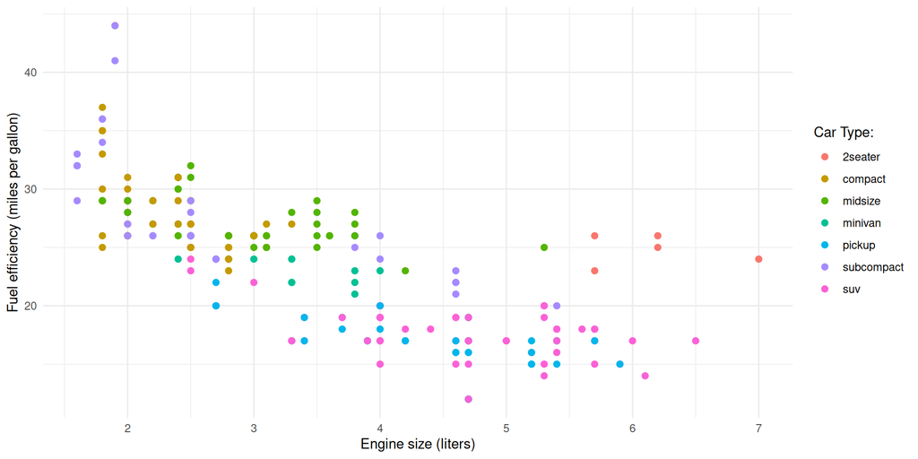

## Model

It’s the only step where “math” enters the game. Goes from simple descriptive statistics, to more elaborated modelling strategies. Often combined with visualisations.

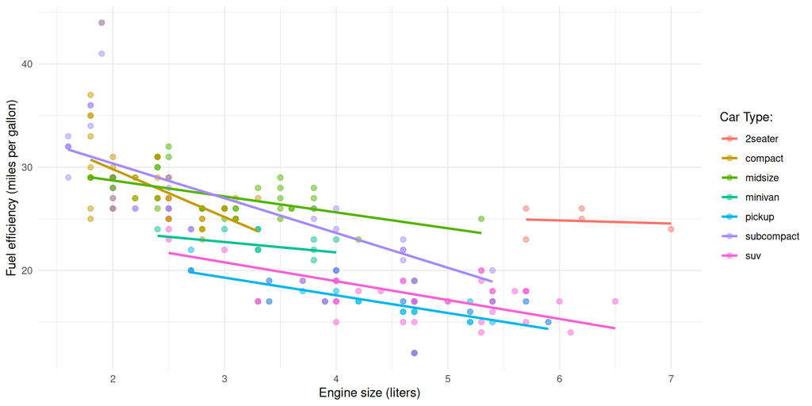

## Communicate

- Write reports;
- Choose appropriate visualizations;
- Highlight the results in terms of insights.

## Why R?

Replicability!

## Excel vs R

- Consider creating a new variable in your dataset:

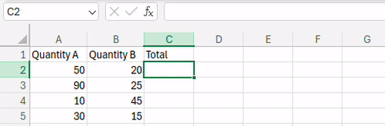

- Now you share your spreadsheet with your colleagues.
- They will not know the formula within each cell unless they inspect all of them individually!

## Excel vs R

- Consider the same data in R, stored in the object `my_data`

```r
my_data
```

```
# A tibble: 4 × 2
  QuantityA QuantityB
      <dbl>     <dbl>
1        50        20
2        90        25
3        10        45
4        30        15
```

- You can create the same `Tot` column you had before in Excel with

```r
my_data |>
  mutate(Tot = QuantityA + QuantityB)
```

```
# A tibble: 4 × 3
  QuantityA QuantityB   Tot
      <dbl>     <dbl> <dbl>
1        50        20    70
2        90        25   115
3        10        45    55
4        30        15    45
```

- And now your colleagues have no doubt about where those numbers come from!

## Excel VS R

- You are interested in computing the total number of products sold by each representative:

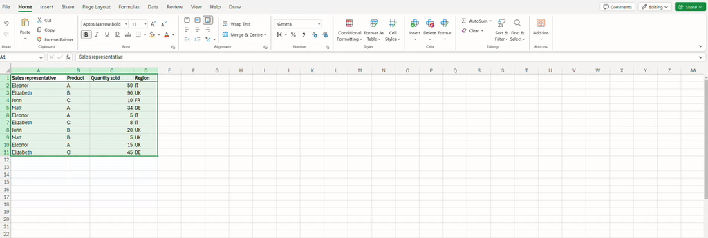

- That’s a lot of point-and-clicks!
- Will your colleague be able to reproduce your results?

## Excel VS R

Consider the same dataset in R stored in the new object `my_data2`:

```r
my_data2
```

```
# A tibble: 10 × 4
   SalesRepresentative Product QuantitySold Region
   <chr>               <chr>          <dbl> <chr>
 1 Eleonor             A                 50 IT
 2 Elizabeth           B                 90 UK
 3 John                C                 10 FR
 4 Matt                A                 34 DE
 5 Eleonor             A                  5 IT
 6 Elizabeth           C                  8 IT
 7 John                B                 20 UK
 8 Matt                B                  5 UK
 9 Eleonor             A                 15 UK
10 Elizabeth           C                 45 DE
```

You get the same results seen in Excel by running

```r
my_data2 |>
  group_by(SalesRepresentative) |>
  summarise(Total = sum(QuantitySold))
```

```
# A tibble: 4 × 2
  SalesRepresentative Total
  <chr>               <dbl>
1 Eleonor                70
2 Elizabeth             143
3 John                   30
4 Matt                   39
```

## RStudio

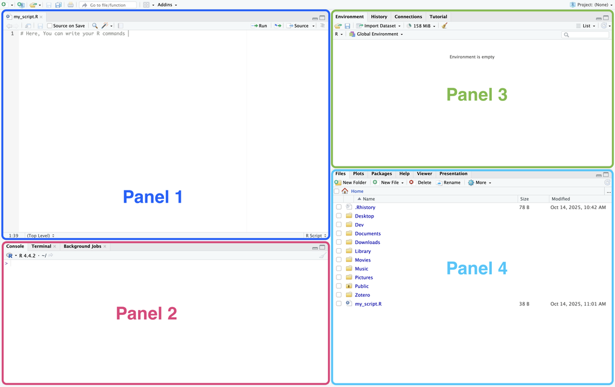

## Basic R grammar

- Run a command:
  - Get the cursor on the line and press CTRL+ENTER on Windows, or CMD+ENTER on MacOS.
- Assign a value to an object

```r
a = 1                            # numeric value assigned with =
b <- 2                           # numeric value assigned with <-
c <- "ciao"                      # character value
c                                # display the content stored in c
```

```
[1] "ciao"
```

- Basic math

```r
a+b                              # sum the values stored in a and b
```

```
[1] 3
```

## Basic R grammar

- Create a vector

```r
v1 <- c(1, 7, 2)                 # create the vector manually
v2 <- 1:10                       # create a sequence 1 to 10 automatically
v3 <- seq(1,10,by=2)             # create a sequence automatically with the seq() function
```

- Create and inspect matrices

```r
m <- matrix(1:6, nrow=2, ncol=3) # create a matrix
nrow(m)                          # inspect the number of rows
```

```
[1] 2
```

```r
ncol(m)                          # inspect the number of columns
```

```
[1] 3
```

```r
m[1,2]                           # display element on the first row, at the second column
```

```
[1] 3
```

## RStudio tips

- **Tab completion**: start typing a function or object name, press `Tab`
- **Insert `<-`**: press `Alt + -` (Windows) or `Option + -` (Mac)
- **Run current line**: `Ctrl+Enter` (Windows) or `Cmd+Enter` (Mac)
- **Environment pane** (top-right): shows all objects you have created
- **Help pane** (bottom-right): displays documentation when you run `?function_name`

## Seeking help

Use `?` or `help()` to open the documentation of any function:

```r
?mean
help(mean)
```

A help page has several sections. Focus on:

- **Arguments**: what inputs the function accepts
- **Examples**: runnable code at the bottom of the page

Example: “How do I ignore `NA`s in `mean()`?”

1. Run `?mean`
2. Scroll to **Arguments** and find `na.rm`
3. It says: *“a logical value indicating whether NA values should be stripped …”*
4. Use `mean(x, na.rm = TRUE)`

## Missing values

In real datasets, some values are often missing. R represents them as `NA`.

```r
x <- c(10, 20, NA, 40)
mean(x)
```

```
[1] NA
```

`NA` is contagious: any operation involving `NA` returns `NA`.

To ignore missing values, use the `na.rm` argument:

```r
mean(x, na.rm = TRUE)
```

```
[1] 23.33333
```

Most summary functions accept `na.rm`: `sum()`, `max()`, `min()`, `sd()`

To detect missing values:

```r
is.na(x)
```

```
[1] FALSE FALSE  TRUE FALSE
```

```r
sum(is.na(x))
```

```
[1] 1
```

## Naming conventions and common mistakes

**Naming conventions:** Since R is case-sensitive (e.g.`Salary` and `salary` are different objects), stick to consistent naming conventions:

- Use `snake_case` for object names: `my_data`, `total_sales`
- Use `camelCase` for object names: `myData`, `totalSales`
- Use `PascalCase` for object names: `MyData`, `TotalSales`

**Common mistakes:**

```r
mean(c(1, 2, 3)
```

Missing closing `)`. R shows `+` and waits. Press **Esc** to cancel.

```r
maen(x)
```

Typo in function name. `Error: could not find function "maen"`

```r
my_vec <- c(10, 20, 40)
MyVec
```

`Error: object 'MyVec' not found`

## Additional types of objects (i)

Logical values: represent a `TRUE/FALSE`statement

```r
# store in the object `my_logical` the answer to "is 3 less than 4?".
# Can only take values TRUE/FALSE
my_logical = 3 < 4
my_logical
```

```
[1] TRUE
```

Factors: categorical variables with known levels

```r
# start from a raw vector of strings
my_raw_var <- c("low", "low", "medium", "low", "high", "high", "medium")
my_raw_var
```

```
[1] "low"    "low"    "medium" "low"    "high"   "high"   "medium"
```

```r
# convert automatically to a factor via `as.factor()`
my_fact <- as.factor(my_raw_var)
my_fact
```

```
[1] low    low    medium low    high   high   medium
Levels: high low medium
```

```r
# manual construction with `factor()` specifying levels ordering
my_fact <- factor(my_raw_var, levels = c("low", "medium", "high"), ordered=TRUE)
my_fact
```

```
[1] low    low    medium low    high   high   medium
Levels: low < medium < high
```

## Additional types of objects (ii)

**Lists:**

List of objects of potentially different nature

```r
my_list <- list(          # use the `list()` function
    "A"=c(0,1,2),
    "B"= "ciao",
    "C"= 2<5
)
my_list
```

```
$A
[1] 0 1 2

$B
[1] "ciao"

$C
[1] TRUE
```

## Data frames

- Matrices in R constrain all columns to have data of the same type (all numeric, all character, etc…).
- Data frames are more convenient objects where to store your data.

```r
var1 <- c("pop-up", "banner", "video")
var2 <- c(56, 23, 321)
var3 <- c(7,2,25)
var4 <- c(TRUE, FALSE, FALSE)
my_df <- data.frame(
    "ad_type"= var1,
    "n_clicks"=var2,
    "sales"=var3,
    "weekend"=var4)
my_df
```

```
  ad_type n_clicks sales weekend
1  pop-up       56     7    TRUE
2  banner       23     2   FALSE
3   video      321    25   FALSE
```

## Data frames attributes

```r
colnames(my_df) # get the column names from my_df
```

```
[1] "ad_type"  "n_clicks" "sales"    "weekend"
```

```r
dim(my_df)       # get the dimensions of my_df
```

```
[1] 3 4
```

```r
my_df$ad_type    # access a column of my_df by name
```

```
[1] "pop-up" "banner" "video"
```

```r
my_df[ , 1]      # access a column by index
```

```
[1] "pop-up" "banner" "video"
```

```r
my_df[2 , ]      # acces a row by index
```

```
  ad_type n_clicks sales weekend
2  banner       23     2   FALSE
```

## Logical comparisons

| Operator | Meaning | Example |
| --- | --- | --- |
| `==` | equal to | `3 == 3` → `TRUE` |
| `!=` | not equal to | `3 != 4` → `TRUE` |
| `<`, `>` | less / greater than | `5 > 2` → `TRUE` |
| `<=`, `>=` | less/greater or equal | `3 >= 3` → `TRUE` |
| `%in%` | is element in a set | `"a" %in% c("a","b")` → `TRUE` |

Combine conditions with `&` (and), `|` (or), `!` (not):

```r
x <- c(10, 25, 5, 40, 15)
x > 10 & x < 30
```

```
[1] FALSE  TRUE FALSE FALSE  TRUE
```

```r
x %in% c(5, 15, 100)
```

```
[1] FALSE FALSE  TRUE FALSE  TRUE
```

## Filtering data.frames

Use `df[condition, ]` to keep only the rows where the condition is `TRUE`:

```r
my_df[my_df$n_clicks > 30, ]
```

```
  ad_type n_clicks sales weekend
1  pop-up       56     7    TRUE
3   video      321    25   FALSE
```

Use `%in%` to match against several values at once:

```r
my_df[my_df$ad_type %in% c("banner", "video"), ]
```

```
  ad_type n_clicks sales weekend
2  banner       23     2   FALSE
3   video      321    25   FALSE
```

You can combine conditions:

```r
my_df[my_df$n_clicks > 10 & my_df$weekend == FALSE, ]
```

```
  ad_type n_clicks sales weekend
2  banner       23     2   FALSE
3   video      321    25   FALSE
```

## The `txhousing` dataset

R comes with several built-in datasets. Today we will use `txhousing` from the `ggplot2` package: monthly housing market data for 46 Texas cities (2000-2015).

```r
head(txhousing)
```

```
# A tibble: 6 × 9
  city     year month sales   volume median listings inventory  date
  <chr>   <int> <int> <dbl>    <dbl>  <dbl>    <dbl>     <dbl> <dbl>
1 Abilene  2000     1    72  5380000  71400      701       6.3 2000
2 Abilene  2000     2    98  6505000  58700      746       6.6 2000.
3 Abilene  2000     3   130  9285000  58100      784       6.8 2000.
4 Abilene  2000     4    98  9730000  68600      785       6.9 2000.
5 Abilene  2000     5   141 10590000  67300      794       6.8 2000.
6 Abilene  2000     6   156 13910000  66900      780       6.6 2000.
```

Variables: `city`, `year`, `month`, `sales`, `volume`, `median` (price), `listings`, `inventory`.

## Exploring a dataset

```r
str(txhousing)
```

```
tibble [8,602 × 9] (S3: tbl_df/tbl/data.frame)
 $ city     : chr [1:8602] "Abilene" "Abilene" "Abilene" "Abilene" ...
 $ year     : int [1:8602] 2000 2000 2000 2000 2000 2000 2000 2000 2000 2000 ...
 $ month    : int [1:8602] 1 2 3 4 5 6 7 8 9 10 ...
 $ sales    : num [1:8602] 72 98 130 98 141 156 152 131 104 101 ...
 $ volume   : num [1:8602] 5380000 6505000 9285000 9730000 10590000 ...
 $ median   : num [1:8602] 71400 58700 58100 68600 67300 66900 73500 75000 64500 59300 ...
 $ listings : num [1:8602] 701 746 784 785 794 780 742 765 771 764 ...
 $ inventory: num [1:8602] 6.3 6.6 6.8 6.9 6.8 6.6 6.2 6.4 6.5 6.6 ...
 $ date     : num [1:8602] 2000 2000 2000 2000 2000 ...
```

```r
summary(txhousing$median)
```

```
   Min. 1st Qu.  Median    Mean 3rd Qu.    Max.     NAs
  50000  100000  123800  128131  150000  304200     616
```

Note: `NA's : 616`. There are missing values!

## A first plot: the axis

```r
ggplot(data = txhousing, aes(x = listings, y = sales))
```

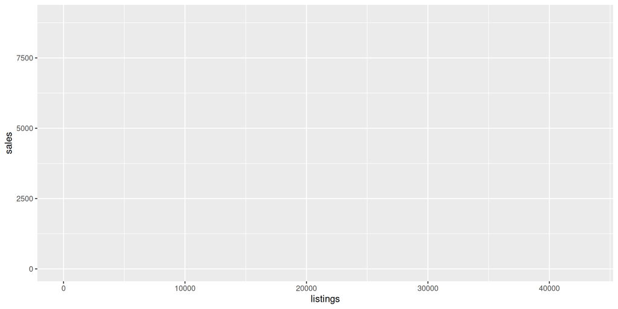

## A first plot: scatterplot

```r
ggplot(data = txhousing, aes(x = listings, y = sales)) +
  geom_point()
```

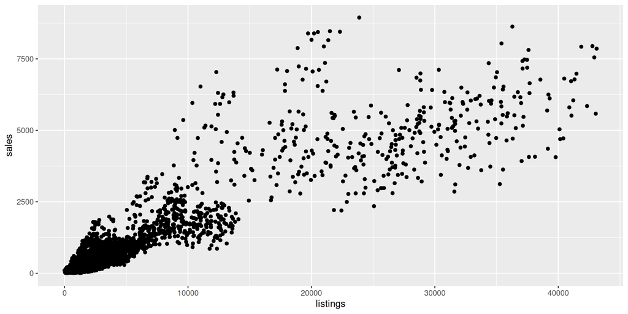

## Adding color

```r
ggplot(data = txhousing, aes(x = listings, y = sales)) +
  geom_point(aes(color = city))
```

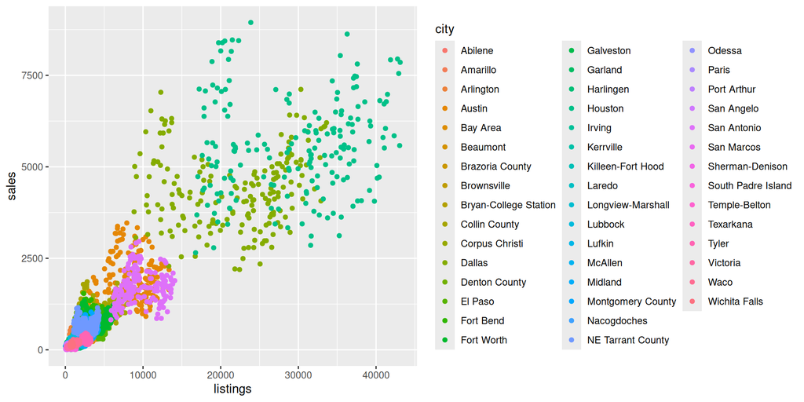

46 cities = too many colors!

## Pre process

```r
new_txhousing <- txhousing[txhousing$city %in% c("Abilene", "Garland", "El Paso"), ]
ggplot(data = new_txhousing, aes(x = listings, y = sales)) +
  geom_point(aes(color = city))
```

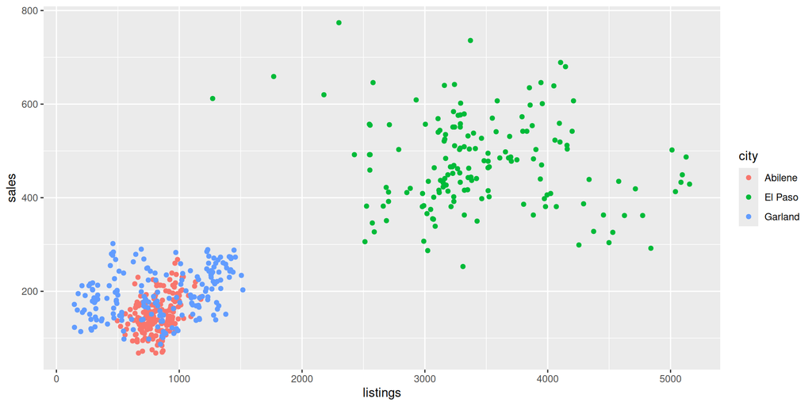

## Modify your plot labels

```r
new_txhousing <- txhousing[txhousing$city %in% c("Abilene", "Garland", "El Paso"), ]
ggplot(data = new_txhousing, aes(x = listings, y = sales)) +
  geom_point(aes(color = city)) +
  labs(
    title = "Texas housing market",
    x = "Active listings",
    y = "Number of sales"
  )
```

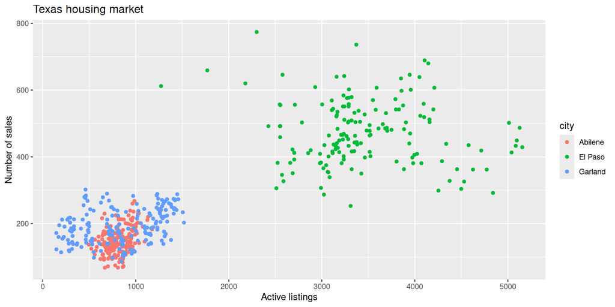

## Visualizing distributions: `geom_histogram()`

```r
ggplot(data = txhousing, aes(x = median)) +
  geom_histogram(bins = 30) +
  labs(x = "Median house price ($)", y = "Count")
```

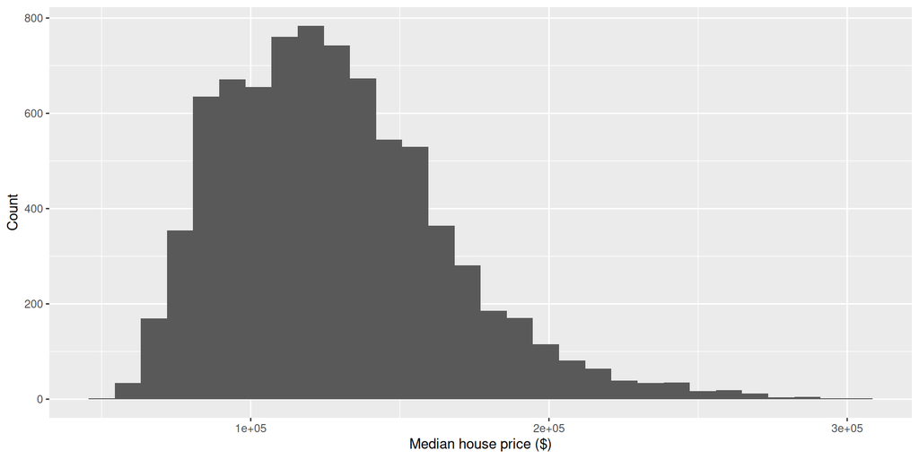

## Visualizing distributions: `geom_histogram()`

```r
ggplot(data = txhousing, aes(x = median)) +
  geom_histogram(bins = 30) +
  labs(x = "Median house price on log scale ($)", y = "Count") +
  scale_x_log10()
```

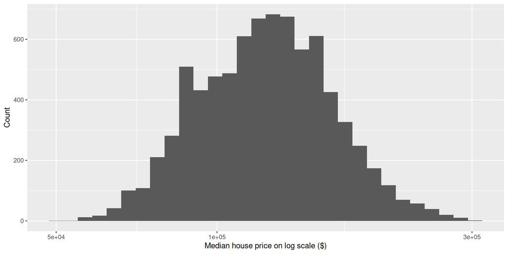

## Visualizing distributions: `geom_histogram()`

```r
ggplot(data = txhousing, aes(x = median)) +
  geom_histogram(bins = 30) +
  labs(x = "Median house price on log scale ($)", y = "Count") +
  scale_x_log10(breaks = seq(10000, 30000000, by = 25000))
```

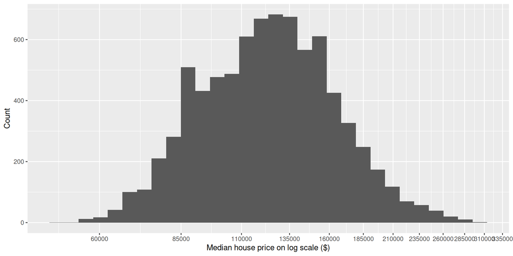

## Visualizing distributions: `geom_histogram()`

```r
ggplot(data = txhousing, aes(x = median)) +
  geom_histogram(bins = 30) +
  labs(x = "Median house price on log scale ($)", y = "Count") +
  scale_x_log10(breaks = seq(10000, 30000000, by = 25000)) +
  theme(axis.text.x = element_text(angle = 45, hjust = 1))
```

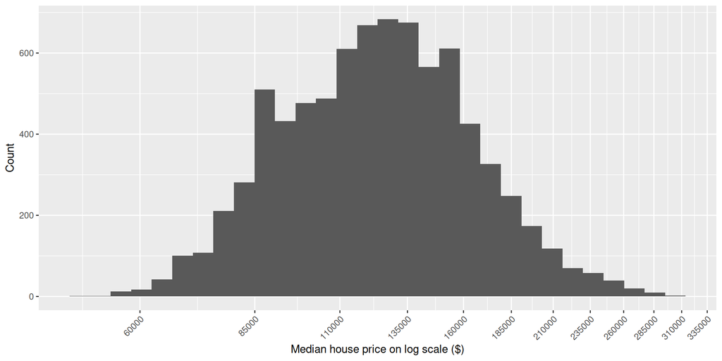

## Visualizing distributions: `geom_histogram()`

```r
ggplot(data = txhousing, aes(x = median)) +
  geom_histogram(bins = 30) +
  labs(x = "Median house price on log scale ($)", y = "Count") +
  scale_x_log10(breaks = seq(10000, 30000000, by = 25000)) +
  theme_bw() +
  theme(axis.text.x = element_text(angle = 45, hjust = 1))
```

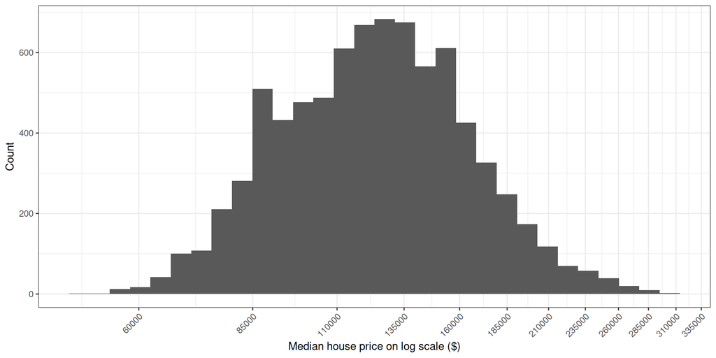

## Visualizing distributions: `geom_histogram()`

```r
ggplot(data = txhousing, aes(x = median)) +
  geom_histogram(bins = 30, fill = "coral3") +
  labs(x = "Median house price on log scale ($)", y = "Count") +
  scale_x_log10(breaks = seq(10000, 30000000, by = 25000)) +
  theme_bw() +
  theme(axis.text.x = element_text(angle = 45, hjust = 1))
```

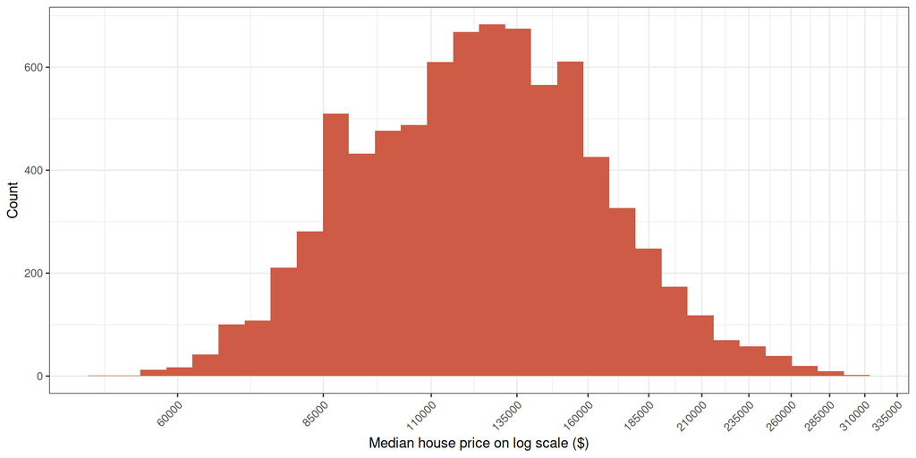

## Visualizing distributions: `geom_histogram()`

```r
ggplot(data = txhousing, aes(x = median)) +
  geom_histogram(bins = 30, fill = "coral3", alpha =.5) +
  labs(x = "Median house price on log scale ($)", y = "Count") +
  scale_x_log10(breaks = seq(10000, 30000000, by = 25000)) +
  theme_bw() +
  theme(axis.text.x = element_text(angle = 45, hjust = 1))
```

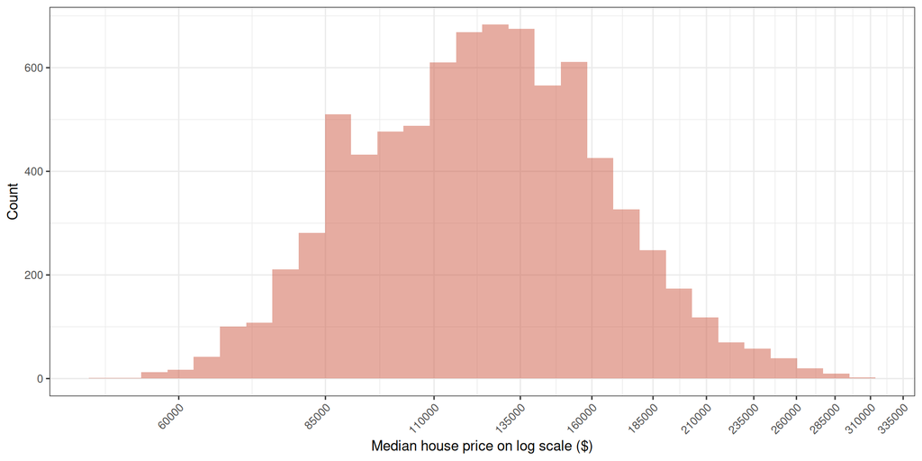

## Visualizing categories: `geom_bar()`

```r
ggplot(data = txhousing, aes(x = factor(year))) +
  geom_bar() +
  labs(x = "Year", y = "Number of monthly records")
```

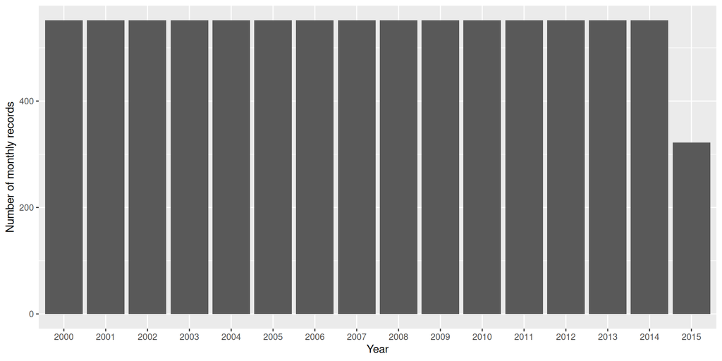

`geom_bar()` counts for you.

## Visualizing categories: `geom_bar()`

```r
ggplot(data = txhousing, aes(x = factor(year), y = sales)) +
  geom_col() +
  labs(x = "Year", y = "Number of monthly records")
```

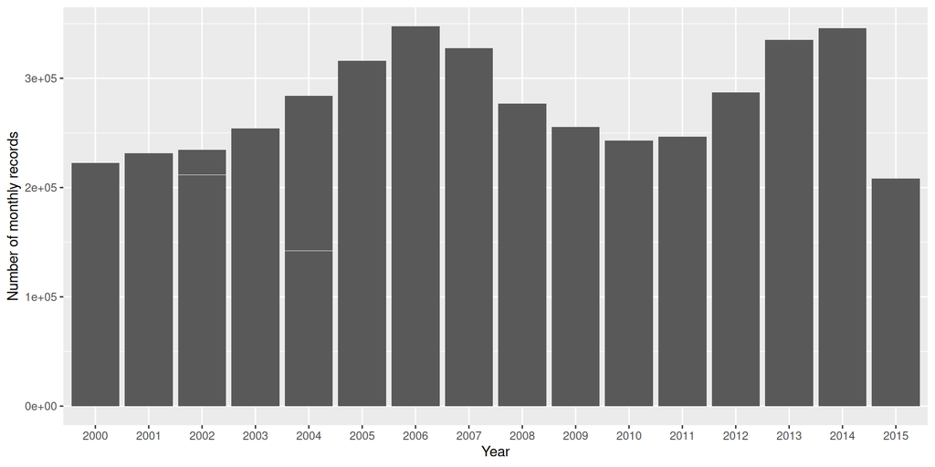

## Comparing groups: `geom_boxplot()`

```r
ggplot(data = txhousing, aes(x = factor(month), y = median)) +
  geom_boxplot() +
  labs(x = "Month", y = "Median house price ($)")
```

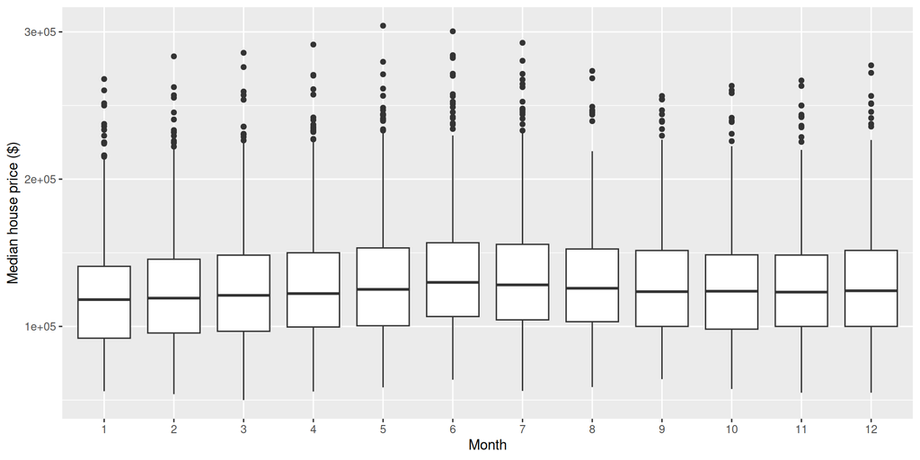

The box = interquartile range (IQR); line inside = median; dots = outliers.

## Multiple panels: `facet_wrap()`

```r
big_cities <- txhousing[txhousing$city %in% c("Houston", "Dallas", "Austin", "San Antonio"), ]
ggplot(data = big_cities, aes(x = listings, y = sales)) +
  geom_point() +
  facet_wrap(~city) +
  labs(x = "Active listings", y = "Number of sales")
```

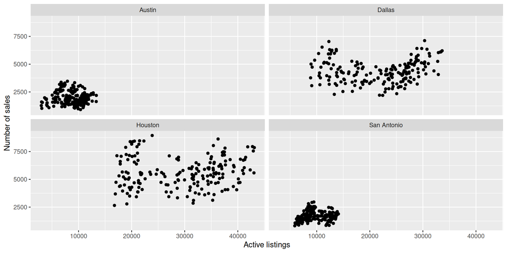

One panel per group, easier to compare patterns.

## Choosing the right plot

Check out the interactive decision tree at data-to-viz.com

## The ggplot recipe

Every plot follows the same pattern:

```r
ggplot(data = ___, aes(x = ___, y = ___)) +
  geom_???() +
  labs(title = ___, x = ___, y = ___) +
  theme_???() +
  ???
```

**You now know 4 geoms:**

| Geom | Use for |
| --- | --- |
| `geom_point()` | Scatterplots (2 numerical variables) |
| `geom_histogram()` | Distribution of 1 numerical variable |
| `geom_bar()` | Counts of 1 categorical variable |
| `geom_boxplot()` | Compare a numerical variable across groups |

Next class: data manipulation, importing files, and more plots.

# Hands-on

## Practice

- Connect to https://giuseppealfonzetti.github.io/LSM/
- Click on the “Material” [(💻)](https://giuseppealfonzetti.github.io/LSM/class1.html) icon corresponding to today lab.